# COVID-19 Data Analysis: Final Project

Kostia

2026-03-02

## Introduction

For this analysis I’m using COVID-19 data from the Johns Hopkins University GitHub repository which tracks confirmed cases and deaths at the US county level with daily updates since January 2020. I’ll be examining whether the relationship between COVID cases and deaths changed after vaccines became widely available in 2021(arbitrary breaking point).

## Data Import

```r
library(tidyverse)
library(lubridate)
```

```r
# Johns Hopkins COVID-19 data
url_in <- "https://raw.githubusercontent.com/CSSEGISandData/COVID-19/master/csse_covid_19_data/csse_covid_19_time_series/"

file_names <- c("time_series_covid19_confirmed_US.csv",
                "time_series_covid19_deaths_US.csv")

urls <- str_c(url_in, file_names)

# Read files
us_cases <- read_csv(urls[1])
us_deaths <- read_csv(urls[2])

# EDA
head(us_cases)
```

```
## # A tibble: 6 × 1,154
##        UID iso2  iso3  code3  FIPS Admin2  Province_State Country_Region   Lat
##      <dbl> <chr> <chr> <dbl> <dbl> <chr>   <chr>          <chr>          <dbl>
## 1 84001001 US    USA     840  1001 Autauga Alabama        US              32.5
## 2 84001003 US    USA     840  1003 Baldwin Alabama        US              30.7
## 3 84001005 US    USA     840  1005 Barbour Alabama        US              31.9
## 4 84001007 US    USA     840  1007 Bibb    Alabama        US              33.0
## 5 84001009 US    USA     840  1009 Blount  Alabama        US              34.0
## 6 84001011 US    USA     840  1011 Bullock Alabama        US              32.1
## # ℹ 1,145 more variables: Long_ <dbl>, Combined_Key <chr>, `1/22/20` <dbl>,
## #   `1/23/20` <dbl>, `1/24/20` <dbl>, `1/25/20` <dbl>, `1/26/20` <dbl>,
## #   `1/27/20` <dbl>, `1/28/20` <dbl>, `1/29/20` <dbl>, `1/30/20` <dbl>,
## #   `1/31/20` <dbl>, `2/1/20` <dbl>, `2/2/20` <dbl>, `2/3/20` <dbl>,
## #   `2/4/20` <dbl>, `2/5/20` <dbl>, `2/6/20` <dbl>, `2/7/20` <dbl>,
## #   `2/8/20` <dbl>, `2/9/20` <dbl>, `2/10/20` <dbl>, `2/11/20` <dbl>,
## #   `2/12/20` <dbl>, `2/13/20` <dbl>, `2/14/20` <dbl>, `2/15/20` <dbl>, …
```

## Data Cleaning

The raw data has each date as a separate column so I’ll pivot it to long format where each date is a row. I’ll also convert the date strings to actual date objects and remove columns I don’t need like coordinates and ID codes. For the deaths dataset I’ll keep the Population column since I’ll need that later to calculate death rates.

```r
us_cases <- us_cases %>%
  pivot_longer(cols = -(UID:Combined_Key),
               names_to = "date",
               values_to = "cases") %>%
  select(Admin2, Province_State, Country_Region, date, cases, Combined_Key) %>%
  mutate(date = mdy(date)) %>%
  filter(cases > 0)

head(us_cases)
```

```
## # A tibble: 6 × 6
##   Admin2  Province_State Country_Region date       cases Combined_Key
##   <chr>   <chr>          <chr>          <date>     <dbl> <chr>
## 1 Autauga Alabama        US             2020-03-24     1 Autauga, Alabama, US
## 2 Autauga Alabama        US             2020-03-25     5 Autauga, Alabama, US
## 3 Autauga Alabama        US             2020-03-26     6 Autauga, Alabama, US
## 4 Autauga Alabama        US             2020-03-27     6 Autauga, Alabama, US
## 5 Autauga Alabama        US             2020-03-28     6 Autauga, Alabama, US
## 6 Autauga Alabama        US             2020-03-29     6 Autauga, Alabama, US
```

```r
us_deaths <- us_deaths %>%
  pivot_longer(cols = -(UID:Population),
               names_to = "date",
               values_to = "deaths") %>%
  select(Admin2, Province_State, Country_Region, date, deaths, Population, Combined_Key) %>%
  mutate(date = mdy(date))

head(us_deaths)
```

```
## # A tibble: 6 × 7
##   Admin2 Province_State Country_Region date       deaths Population Combined_Key
##   <chr>  <chr>          <chr>          <date>      <dbl>      <dbl> <chr>
## 1 Autau… Alabama        US             2020-01-22      0      55869 Autauga, Al…
## 2 Autau… Alabama        US             2020-01-23      0      55869 Autauga, Al…
## 3 Autau… Alabama        US             2020-01-24      0      55869 Autauga, Al…
## 4 Autau… Alabama        US             2020-01-25      0      55869 Autauga, Al…
## 5 Autau… Alabama        US             2020-01-26      0      55869 Autauga, Al…
## 6 Autau… Alabama        US             2020-01-27      0      55869 Autauga, Al…
```

```r
# Join
us <- us_cases %>%
  full_join(us_deaths)

summary(us)
```

```
##     Admin2          Province_State     Country_Region          date
##  Length:3819906     Length:3819906     Length:3819906     Min.   :2020-01-22
##  Class :character   Class :character   Class :character   1st Qu.:2020-11-02
##  Mode  :character   Mode  :character   Mode  :character   Median :2021-08-15
##                                                           Mean   :2021-08-15
##                                                           3rd Qu.:2022-05-28
##                                                           Max.   :2023-03-09
##
##      cases         Combined_Key           deaths          Population
##  Min.   :      1   Length:3819906     Min.   :  -82.0   Min.   :       0
##  1st Qu.:    687   Class :character   1st Qu.:    4.0   1st Qu.:    9917
##  Median :   2849   Mode  :character   Median :   37.0   Median :   24892
##  Mean   :  15489                      Mean   :  186.9   Mean   :   99604
##  3rd Qu.:   9345                      3rd Qu.:  122.0   3rd Qu.:   64979
##  Max.   :3710586                      Max.   :35545.0   Max.   :10039107
##  NA's   :345614
```

## Aggregating to National Level

To look at the overall US trend I need to sum up all the county-level data by date to get national totals.

```r
us_totals <- us %>%
  group_by(Country_Region, date) %>%
  summarize(cases = sum(cases, na.rm = TRUE),
            deaths = sum(deaths, na.rm = TRUE),
            Population = sum(Population, na.rm = TRUE),
            .groups = "drop") %>%
  mutate(deaths_per_mill = deaths * 1000000 / Population) %>%
  filter(cases > 0)

tail(us_totals)
```

```
## # A tibble: 6 × 6
##   Country_Region date           cases  deaths Population deaths_per_mill
##   <chr>          <date>         <dbl>   <dbl>      <dbl>           <dbl>
## 1 US             2023-03-04 103650837 1122172  332875137           3371.
## 2 US             2023-03-05 103646975 1122134  332875137           3371.
## 3 US             2023-03-06 103655539 1122181  332875137           3371.
## 4 US             2023-03-07 103690910 1122516  332875137           3372.
## 5 US             2023-03-08 103755771 1123246  332875137           3374.
## 6 US             2023-03-09 103802702 1123836  332875137           3376.
```

## Visualization 1: Cumulative US Cases and Deaths Over Time

This visual looks at how total COVID cases and deaths accumulated in the United States from the beginning of the pandemic.

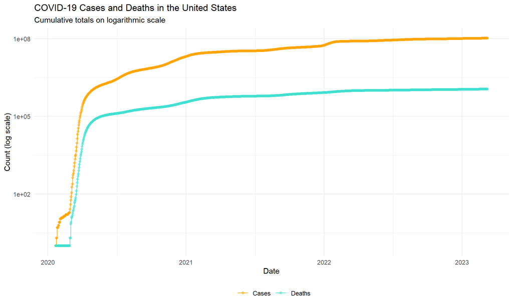

```r
us_totals %>%
  ggplot(aes(x = date)) +
  geom_line(aes(y = cases, color = "Cases")) +
  geom_point(aes(y = cases, color = "Cases"), alpha = 0.5) +
  geom_line(aes(y = deaths, color = "Deaths")) +
  geom_point(aes(y = deaths, color = "Deaths"), alpha = 0.5) +
  scale_y_log10() +
  scale_color_manual(values = c("Cases" = "orange", "Deaths" = "turquoise")) +
  labs(
    title = "COVID-19 Cases and Deaths in the United States",
    subtitle = "Cumulative totals on logarithmic scale",
    x = "Date",
    y = "Count (log scale)",
    color = ""
  ) +
  theme_minimal() +
  theme(legend.position = "bottom")
```

### Visualization 1: Key Takeaways

The graph shows both cases and deaths growing exponentially at first and then the growth plateaus. I used a log scale on the y-axis because otherwise the early part of the pandemic would be impossible to see. It looks like the gap between the cases and deaths slightly increases over time, but what’s interesting is that the growth of this gap is caused by an increase in cases with deaths remaining at about the same level. This raises a question about whether treatment got better so smaller proportion of people died, or was it caused by the fact that later we resumed travel which made younger people who have less likelihood of dying from the virus get infected more often.

## Calculating New Cases and Deaths

To see whether the pandemic was getting better or worse at different points I need to calculate new cases per day instead of just cumulative totals.

```r
us_totals <- us_totals %>%
  mutate(
    new_cases = cases - lag(cases),
    new_deaths = deaths - lag(deaths)
  )

tail(us_totals %>% select(date, new_cases, new_deaths, cases, deaths))
```

```
## # A tibble: 6 × 5
##   date       new_cases new_deaths     cases  deaths
##   <date>         <dbl>      <dbl>     <dbl>   <dbl>
## 1 2023-03-04      2147          7 103650837 1122172
## 2 2023-03-05     -3862        -38 103646975 1122134
## 3 2023-03-06      8564         47 103655539 1122181
## 4 2023-03-07     35371        335 103690910 1122516
## 5 2023-03-08     64861        730 103755771 1123246
## 6 2023-03-09     46931        590 103802702 1123836
```

## Defining Vaccination Periods

Vaccines became available to the general public around January 2021. I’ll split the data into pre-vaccination and post-vaccination periods using that date as the cutoff.

```r
us_totals <- us_totals %>%
  mutate(
    period = if_else(date < as.Date("2021-01-01"),
                     "Pre-Vaccination",
                     "Post-Vaccination")
  )

us_totals %>%
  group_by(period) %>%
  summarize(
    n_days = n(),
    total_cases = max(cases, na.rm = TRUE),
    total_deaths = max(deaths, na.rm = TRUE)
  )
```

```
## # A tibble: 2 × 4
##   period           n_days total_cases total_deaths
##   <chr>             <int>       <dbl>        <dbl>
## 1 Post-Vaccination    798   103802702      1123836
## 2 Pre-Vaccination     345    20219881       350604
```

## Visualization 2: New Cases by Vaccination Period

Now I’ll plot daily new cases and color them by whether they happened before or after vaccines became available to see if patterns changed.

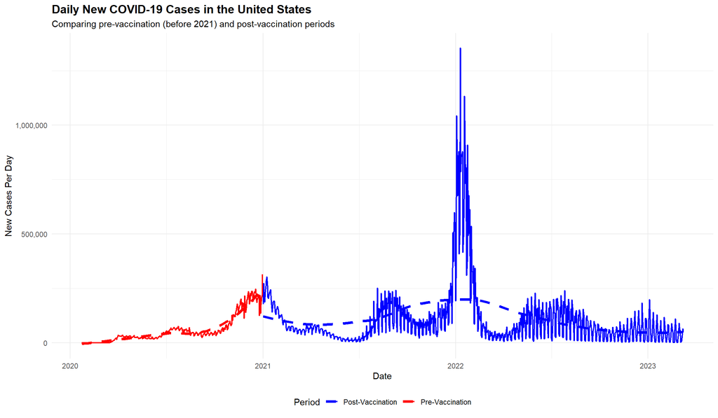

```r
us_totals %>%
  filter(!is.na(new_cases) & new_cases >= 0) %>%
  ggplot(aes(x = date, y = new_cases, color = period)) +
  geom_line(size = 0.8) +
  geom_smooth(se = FALSE, size = 1.5, linetype = "dashed") +
  scale_color_manual(values = c("Pre-Vaccination" = "red",
                                 "Post-Vaccination" = "blue")) +
  scale_y_continuous(labels = scales::comma) +
  labs(
    title = "Daily New COVID-19 Cases in the United States",
    subtitle = "Comparing pre-vaccination (before 2021) and post-vaccination periods",
    x = "Date",
    y = "New Cases Per Day",
    color = "Period"
  ) +
  theme_minimal() +
  theme(legend.position = "bottom",
        plot.title = element_text(size = 14, face = "bold"))
```

### Visualization 2: Key Takeaways

This graph is interesting because it shows that some of the biggest spikes in daily new cases happened after vaccines were already available. The red section shows the pre-vaccination period had some major waves but the blue post-vaccination period had peaks that were even higher especially in late 2021 and early 2022. The dashed trend lines show that on average new cases were actually higher in the post-vaccination period than before which seems counterintuitive. But one thing that I don’t think we account for in the data is any of the quarantine measures taken by different locations. I wonder if the spikes in 2022 were also at least partially caused by the fact that people got tired of all the restrictions or even the fact that by late 2022, COVID seemed like something from the past and thus people relaxed a touch too much.

## Linear Regression Model: New Deaths vs New Cases by Period

To test whether vaccines changed the relationship between cases and deaths I’ll fit a linear regression model that predicts new deaths from new cases with an interaction term for the vaccination period.

```r
# aggregate weekly data
us_weekly <- us_totals %>%
  filter(!is.na(new_cases) & !is.na(new_deaths)) %>%
  mutate(week = floor_date(date, "week")) %>%
  group_by(week, period) %>%
  summarize(
    avg_new_cases = mean(new_cases, na.rm = TRUE),
    avg_new_deaths = mean(new_deaths, na.rm = TRUE),
    .groups = "drop"
  ) %>%
  filter(avg_new_cases >= 0 & avg_new_deaths >= 0)

head(us_weekly, 10)
```

```
## # A tibble: 10 × 4
##    week       period          avg_new_cases avg_new_deaths
##    <date>     <chr>                   <dbl>          <dbl>
##  1 2020-01-19 Pre-Vaccination         0.333          0
##  2 2020-01-26 Pre-Vaccination         0.857          0
##  3 2020-02-02 Pre-Vaccination         0.571          0
##  4 2020-02-09 Pre-Vaccination         0.286          0
##  5 2020-02-16 Pre-Vaccination         0.286          0
##  6 2020-02-23 Pre-Vaccination         1.43           0.143
##  7 2020-03-01 Pre-Vaccination        55.9            2.29
##  8 2020-03-08 Pre-Vaccination       362.             6.14
##  9 2020-03-15 Pre-Vaccination      3301.            60.1
## 10 2020-03-22 Pre-Vaccination     14480.           362.
```

I’m using weekly averages to avoid noise from reporting delays and weekend effects.

```r
# Fitmodel
model <- lm(avg_new_deaths ~ avg_new_cases * period, data = us_weekly)

summary(model)
```

```
##
## Call:
## lm(formula = avg_new_deaths ~ avg_new_cases * period, data = us_weekly)
##
## Residuals:
##     Min      1Q  Median      3Q     Max
## -1085.7  -453.2  -217.9   264.4  2026.3
##
## Coefficients:
##                                       Estimate Std. Error t value Pr(>|t|)
## (Intercept)                          6.511e+02  7.828e+01   8.318 3.58e-14 ***
## avg_new_cases                        3.088e-03  4.723e-04   6.537 7.89e-10 ***
## periodPre-Vaccination               -1.485e+02  1.482e+02  -1.002  0.31773
## avg_new_cases:periodPre-Vaccination  5.647e-03  1.535e-03   3.678  0.00032 ***
## ---
## Signif. codes:  0 '***' 0.001 '**' 0.01 '*' 0.05 '.' 0.1 ' ' 1
##
## Residual standard error: 648.3 on 161 degrees of freedom
## Multiple R-squared:  0.3281, Adjusted R-squared:  0.3156
## F-statistic: 26.21 on 3 and 161 DF,  p-value: 7.36e-14
```

### Model Interpretation

```r
# Add predictions
us_weekly <- us_weekly %>%
  mutate(predicted_deaths = predict(model))

head(us_weekly %>% select(week, period, avg_new_cases, avg_new_deaths, predicted_deaths), 10)
```

```
## # A tibble: 10 × 5
##    week       period          avg_new_cases avg_new_deaths predicted_deaths
##    <date>     <chr>                   <dbl>          <dbl>            <dbl>
##  1 2020-01-19 Pre-Vaccination         0.333          0                 503.
##  2 2020-01-26 Pre-Vaccination         0.857          0                 503.
##  3 2020-02-02 Pre-Vaccination         0.571          0                 503.
##  4 2020-02-09 Pre-Vaccination         0.286          0                 503.
##  5 2020-02-16 Pre-Vaccination         0.286          0                 503.
##  6 2020-02-23 Pre-Vaccination         1.43           0.143             503.
##  7 2020-03-01 Pre-Vaccination        55.9            2.29              503.
##  8 2020-03-08 Pre-Vaccination       362.             6.14              506.
##  9 2020-03-15 Pre-Vaccination      3301.            60.1               531.
## 10 2020-03-22 Pre-Vaccination     14480.           362.                629.
```

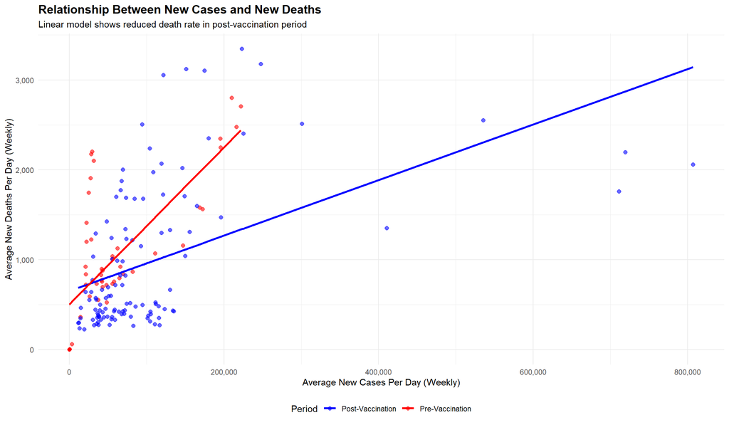

```r
ggplot(us_weekly, aes(x = avg_new_cases, y = avg_new_deaths, color = period)) +
  geom_point(alpha = 0.6, size = 2) +
  geom_line(aes(y = predicted_deaths), size = 1.2) +
  scale_color_manual(values = c("Pre-Vaccination" = "red",
                                 "Post-Vaccination" = "blue")) +
  scale_x_continuous(labels = scales::comma) +
  scale_y_continuous(labels = scales::comma) +
  labs(
    title = "Relationship Between New Cases and New Deaths",
    subtitle = "Linear model shows reduced death rate in post-vaccination period",
    x = "Average New Cases Per Day (Weekly)",
    y = "Average New Deaths Per Day (Weekly)",
    color = "Period"
  ) +
  theme_minimal() +
  theme(legend.position = "bottom",
        plot.title = element_text(size = 14, face = "bold"))
```

### Model Takeaways

The visualization shows that the slope of the relationship between cases and deaths is steeper in the pre-vaccination period compared to post-vaccination. The red dots and line show that before vaccines the same number of new cases led to more deaths while the blue dots and line show a flatter slope, which means that fewer deaths per case after vaccines happaned. There’s still a lot of scatter in the points especially in the post-vaccination period .This means other factors beyond just vaccination are affecting death rates like new variants, treatment improvements and/or changes in who’s getting infected. But the overall pattern sugests that vaccines reduced the severity of COVID infections.

## Bias Discussion

Before drawing final conclusions we need to look at possible biasis

**Testing Availability Changed Over Time** Early pandemic testing was extremely limited so we were definitely undercounting cases.

**Reporting Practices Weren’t Consistent** Different states used different systems for counting COVID deaths and the definitions changed over time. It is unclear if data counts only pure COVID deaths or also includes any where COVID was just a contributing factor

**Other Factors Changed Besides Vaccines** Treatment has improved over time with new drugs and strategies becoming available. Moreover, we are exclusing any considiration of different variants of COVID visous.

## Conclusion

This analysis shows that COVID cases and deaths in the US grew exponentially at first and then went through multiple waves over the past few years. The most important finding is that after vaccines became widely available in 2021 the relationship between new cases and new deaths changed with the same number of cases resulting in fewer deaths(per model results). However the data limitations like inconsistent reporting across states and many confounding factors that make it hard to isolate the vaccine effect.